# BASICS OF MACHINE LANGUAGE FINAL ASSIGNMENT

Harish Kumar uddandi

## R Markdown

```r
library(caret)
library(ISLR)
library(factoextra)
library(tidyverse)
library(flexclust)
library(cluster)
library(gridExtra)
```

#Loading dataset

```r
data<-read.csv("C:/FALL/ML/fuel_receipts_costs_eia923.csv")
str(data)
```

```
## 'data.frame':    608565 obs. of  23 variables:
##  $ rowid                                  : int  1 2 3 4 5 6 7 8 9 10 ...
##  $ plant_id_eia                           : int  3 3 3 7 7 7 7 8 8 8 ...
##  $ report_date                            : chr  "1/1/2008" "1/1/2008" "1/1/2008" "1/1/2008" ...
##  $ contract_type_code                     : chr  "C" "C" "C" "C" ...
##  $ contract_expiration_date               : chr  "4/1/2008" "4/1/2008" "" "12/1/2015" ...
##  $ energy_source_code                     : chr  "BIT" "BIT" "NG" "BIT" ...
##  $ fuel_type_code_pudl                    : chr  "coal" "coal" "gas" "coal" ...
##  $ fuel_group_code                        : chr  "coal" "coal" "natural_gas" "coal" ...
##  $ mine_id_pudl                           : int  0 0 NA 1 2 3 NA 4 4 1 ...
##  $ supplier_name                          : chr  "interocean coal" "interocean coal" "bay gas pipeline" "alabama coal" ...
##  $ fuel_received_units                    : int  259412 52241 2783619 25397 764 603 2341 8869 75442 206741 ...
##  $ fuel_mmbtu_per_unit                    : num  23.1 22.8 1.04 24.61 24.45 ...
##  $ sulfur_content_pct                     : num  0.49 0.48 0 1.69 0.84 1.54 0 2.16 1.24 1.9 ...
##  $ ash_content_pct                        : num  5.4 5.7 0 14.7 15.5 14.6 0 15.4 11.9 15.4 ...
##  $ mercury_content_ppm                    : num  NA NA NA NA NA NA NA NA NA NA ...
##  $ fuel_cost_per_mmbtu                    : num  2.13 2.12 8.63 2.78 3.38 ...
##  $ primary_transportation_mode_code       : chr  "RV" "RV" "PL" "TR" ...
##  $ secondary_transportation_mode_code     : chr  "" "" "" "" ...
##  $ natural_gas_transport_code             : chr  "firm" "firm" "firm" "firm" ...
##  $ natural_gas_delivery_contract_type_code: chr  "" "" "" "" ...
##  $ moisture_content_pct                   : num  NA NA NA NA NA NA NA NA NA NA ...
##  $ chlorine_content_ppm                   : int  NA NA NA NA NA NA NA NA NA NA ...
##  $ data_maturity                          : chr  "final" "final" "final" "final" ...
```

#selecting attributes

```r
data_df<-data[,c(8,12,13,14,16)]
str(data_df)
```

```
## 'data.frame':    608565 obs. of  5 variables:
##  $ fuel_group_code    : chr  "coal" "coal" "natural_gas" "coal" ...
##  $ fuel_mmbtu_per_unit: num  23.1 22.8 1.04 24.61 24.45 ...
##  $ sulfur_content_pct : num  0.49 0.48 0 1.69 0.84 1.54 0 2.16 1.24 1.9 ...
##  $ ash_content_pct    : num  5.4 5.7 0 14.7 15.5 14.6 0 15.4 11.9 15.4 ...
##  $ fuel_cost_per_mmbtu: num  2.13 2.12 8.63 2.78 3.38 ...
```

```r
colMeans(is.na(data_df))
```

```
##     fuel_group_code fuel_mmbtu_per_unit  sulfur_content_pct     ash_content_pct
##           0.0000000           0.0000000           0.0000000           0.0000000
## fuel_cost_per_mmbtu
##           0.3290363
```

#Data Imputing

```r
data_df$fuel_cost_per_mmbtu[is.na(data_df$fuel_cost_per_mmbtu)] <- mean(data_df$fuel_cost_per_mmbtu, na.rm = TRUE)
colMeans(is.na(data_df))  #all the missing values has been imputed
```

```
##     fuel_group_code fuel_mmbtu_per_unit  sulfur_content_pct     ash_content_pct
##                   0                   0                   0                   0
## fuel_cost_per_mmbtu
##                   0
```

#.sampling and partition of the data

```r
set.seed(2424)
sample_data <- data_df[sample(nrow(data_df), size = 13500, replace = FALSE), ]
train_index <- createDataPartition(sample_data$fuel_cost_per_mmbtu, p=0.75, list = FALSE)
train_data<- sample_data[train_index,]
test_data<- sample_data[-train_index,]
```

# normalization of the data.

```r
cluster_data <- train_data %>% select( 'ash_content_pct', 'sulfur_content_pct','fuel_mmbtu_per_unit','fuel_cost_per_mmbtu')

cluster_train <- preProcess(cluster_data, method = "range")
cluster_predict <- predict(cluster_train, cluster_data)

summary(cluster_predict)
```

```
##  ash_content_pct   sulfur_content_pct fuel_mmbtu_per_unit fuel_cost_per_mmbtu
##  Min.   :0.00000   Min.   :0.00000    Min.   :0.00000     Min.   :0.0000000
##  1st Qu.:0.00000   1st Qu.:0.00000    1st Qu.:0.03155     1st Qu.:0.0002493
##  Median :0.00000   Median :0.00000    Median :0.03272     Median :0.0004398
##  Mean   :0.05430   Mean   :0.07506    Mean   :0.29337     Mean   :0.0009076
##  3rd Qu.:0.08882   3rd Qu.:0.07091    3rd Qu.:0.59296     3rd Qu.:0.0013309
##  Max.   :1.00000   Max.   :1.00000    Max.   :1.00000     Max.   :1.0000000
```

#Elbow and Silhouette methods are used to find the optimal number of clusters. #Elbow Method

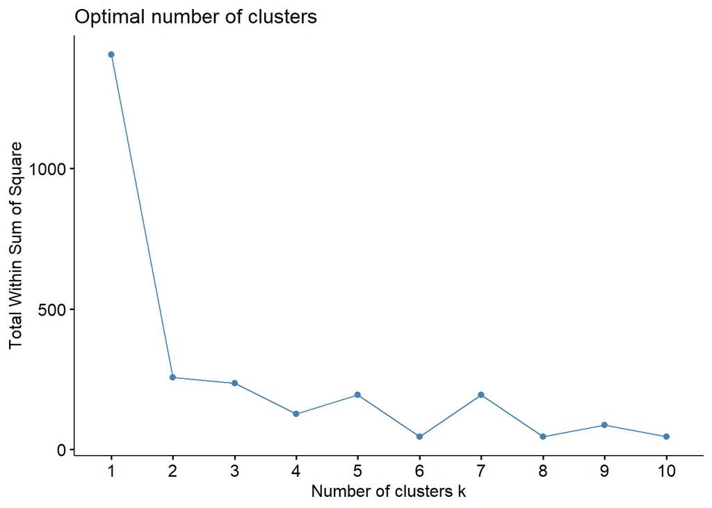

```r
library(factoextra) # clustering algorithms & visualization
library(flexclust)
fviz_nbclust(cluster_predict,kmeans,method="wss")
```

#Silhouttes method

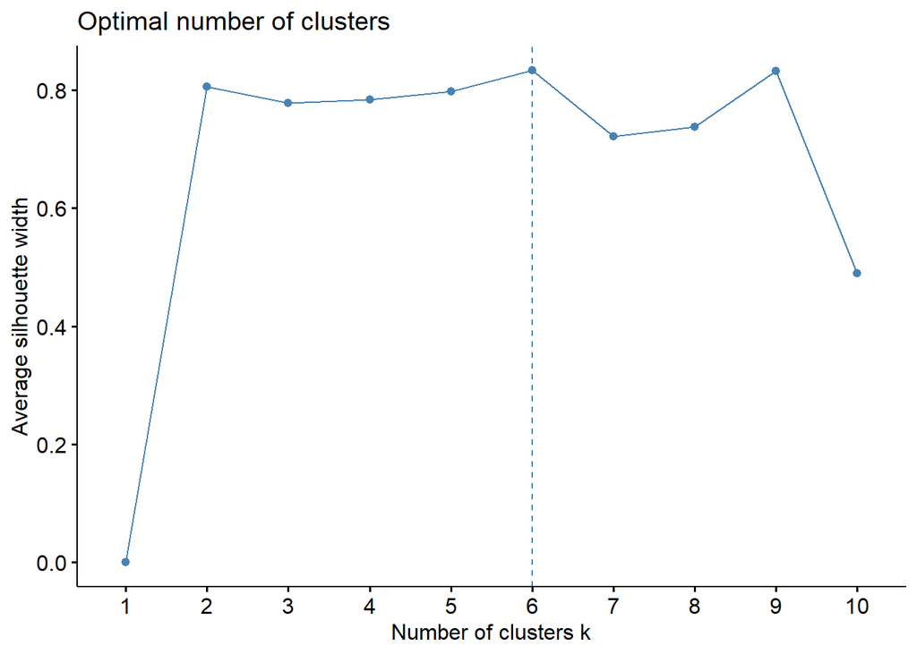

```r
#Silhouttes method
fviz_nbclust(cluster_predict,kmeans,method="silhouette")
```

#As observed in elbow method, the optimal clusters identified as 2, but when we have used Silhouttes method, we got the value as 6. As the elbow method was not clear in determining the optimal cluster, we shall use Silhouttes method here #We have identified the number of clusters. Now we shall apply K-means algorithm

```r
#Applying K-means Algorithm
KMean_chk <- kmeans(cluster_predict, centers = 6, nstart = 25) #Number of restarts = 25
```

#Centers

```r
KMean_chk$centers
```

```
##   ash_content_pct sulfur_content_pct fuel_mmbtu_per_unit fuel_cost_per_mmbtu
## 1    1.465087e-01         0.46727151          0.79613549        0.0005826013
## 2    1.648348e-01         0.15590428          0.80950591        0.0005792193
## 3    6.710601e-05         0.02692564          0.19251079        0.0015399202
## 4    8.646250e-02         0.04652277          0.57698279        0.0004115665
## 5    6.037410e-01         0.19292950          0.44180138        0.0012258850
## 6    0.000000e+00         0.00000000          0.03165675        0.0010494599
```

#Plotting the cluster using k K-means Algorithm

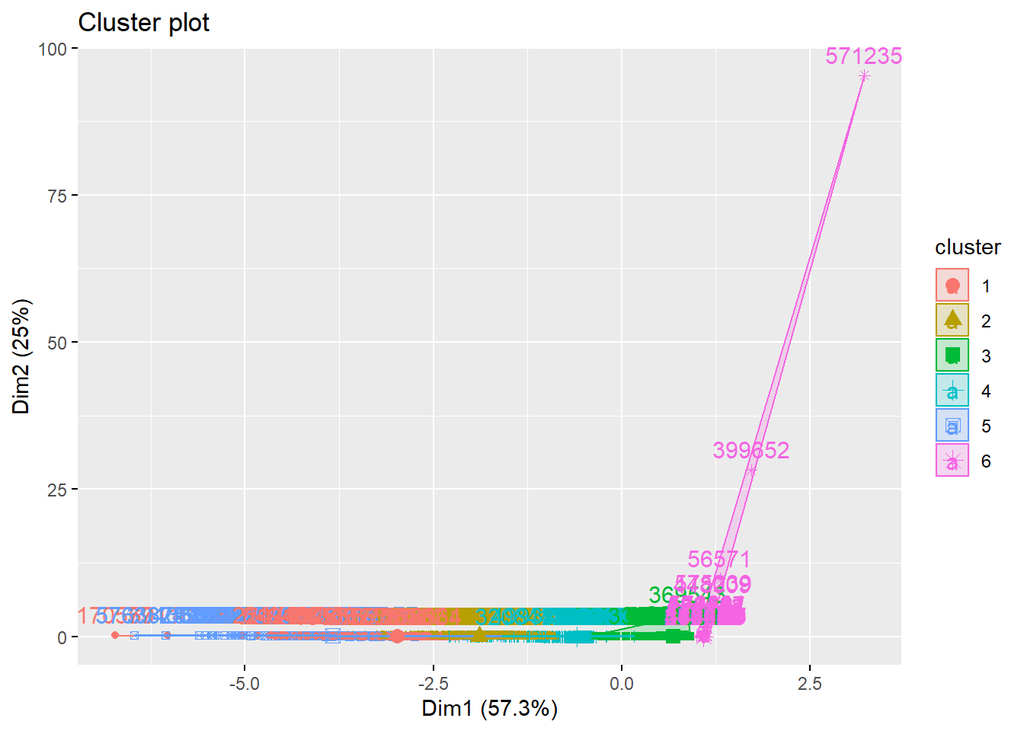

```r
fviz_cluster(KMean_chk, data = cluster_data)
```

#Plotting the Sillohuette average

```
##   cluster size ave.sil.width
## 1       1  962          0.49
## 2       2 1266          0.53
## 3       3  890          0.75
## 4       4 1338          0.81
## 5       5  140          0.45
## 6       6 5531          0.99
```

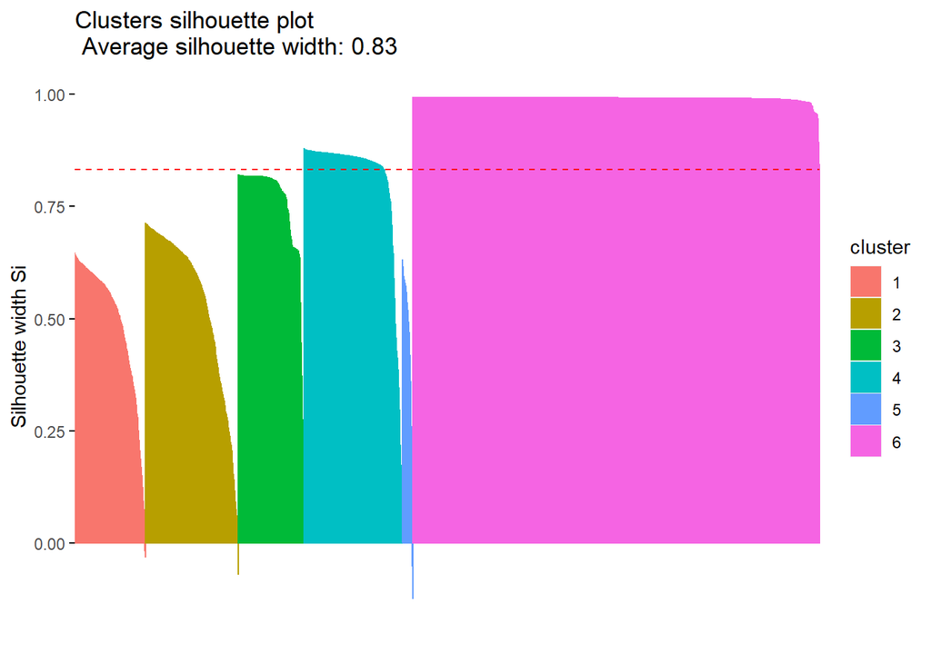

```r
si <- silhouette(KMean_chk$cluster, dist(cluster_predict))
fviz_silhouette(si)
```

#Hence Si(silHouetee coeffient ) value > 0 , i.e 0.83, hence it is a good clustered.

#The final cluster

```r
fcluster<- KMean_chk$cluster
f_cluster<- cbind(train_data, fcluster)
f_cluster$fcluster<-as.factor(f_cluster$fcluster)
head(f_cluster)
```

|  | fuel_group_code | fuel_mmbtu_per_unit | sulfur_content_pct | ash_content_pct | fuel_cost_per_mmbtu | fcluster |
| --- | --- | --- | --- | --- | --- | --- |
| 32310 | coal | 23.980 | 1.14 | 12.8 | 3.73700 | 2 |
| 591187 | natural_gas | 1.036 | 0.00 | 0.0 | 3.41000 | 6 |
| 454496 | natural_gas | 1.084 | 0.00 | 0.0 | 14.18427 | 6 |
| 181440 | coal | 17.630 | 0.22 | 4.6 | 14.18427 | 4 |
| 145791 | natural_gas | 1.006 | 0.00 | 0.0 | 4.63100 | 6 |
| 224681 | natural_gas | 1.030 | 0.00 | 0.0 | 14.18427 | 6 |

# We find the mean of all the quantitative variables

```r
f_cluster%>%group_by(fcluster)%>%
  summarize(
    fuel_mmbtu_per_unit=mean(fuel_mmbtu_per_unit),
            fuel_cost_per_mmbtu=mean(fuel_cost_per_mmbtu),
            sulfur_content=mean(sulfur_content_pct),
    ash_content=mean(ash_content_pct))
```

| fcluster | fuel_mmbtu_per_unit | fuel_cost_per_mmbtu | sulfur_content | ash_content |
| --- | --- | --- | --- | --- |
| 1 | 23.952123 | 6.270548 | 3.2288462 | 9.567016632 |
| 2 | 24.353035 | 6.234780 | 1.0772986 | 10.763712480 |
| 3 | 5.852436 | 16.395081 | 0.1860562 | 0.004382022 |
| 4 | 17.380829 | 4.461696 | 0.3214723 | 5.646001495 |
| 5 | 13.327414 | 13.073868 | 1.3331429 | 39.424285714 |
| 6 | 1.029228 | 11.208009 | 0.0000000 | 0.000000000 |

# Plotting number of ash contents

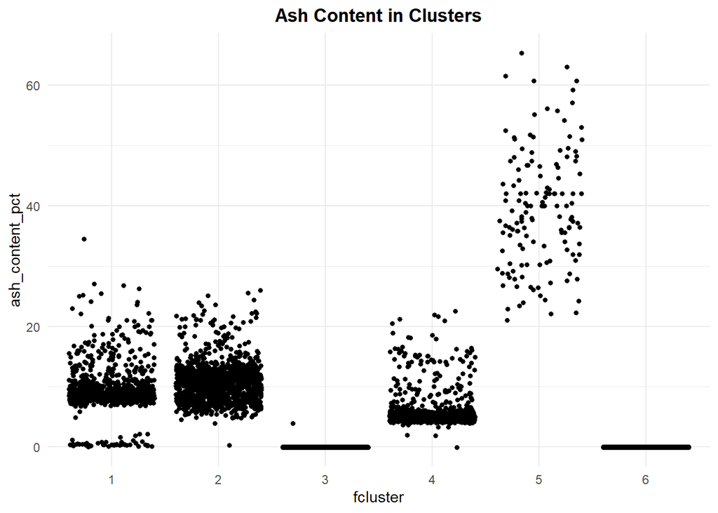

```r
ggplot(f_cluster) +
  aes(x = fcluster, y = ash_content_pct) +
  geom_jitter(size = 1.2) +
  labs(title = "Ash Content in Clusters") +
  theme_minimal() +
  theme(plot.title = element_text(face = "bold", hjust = 0.5))
```

# Plotting number of clusters

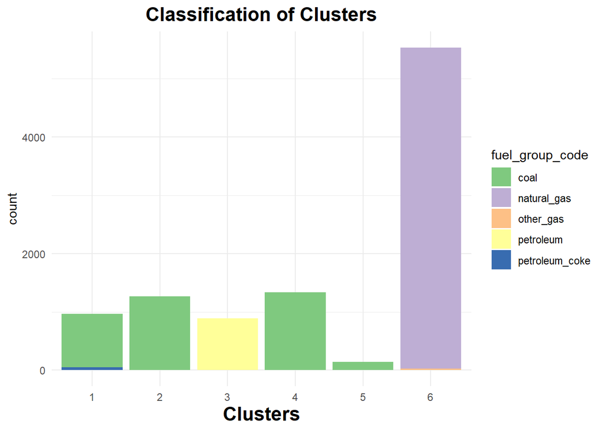

```r
ggplot(f_cluster) +

  aes(x = fcluster, fill = fuel_group_code) +

  geom_bar() +

  scale_fill_brewer(palette = "Accent", direction = 1) +

  labs(x = "Clusters", title = "Classification of Clusters") +

  theme_minimal() +

  theme(

    plot.title = element_text(size = 16L,

    face = "bold",

    hjust = 0.5),

    axis.title.x = element_text(size = 16L,

    face = "bold")

  )
```

#Use multiple-linear regression to determine the best set of variables to predict fuel_cost_per_mmbtu.

#training data

```r
ML_df<- f_cluster
fuel<-ML_df[,-c(1)]
fuel_ML<- preProcess(fuel, method = "range")
fuel_predict <- predict(fuel_ML, fuel)
head(fuel_predict)
```

|  | fuel_mmbtu_per_unit | sulfur_content_pct | ash_content_pct | fuel_cost_per_mmbtu | fcluster |
| --- | --- | --- | --- | --- | --- |
| 32310 | 0.79706520 | 0.16497829 | 0.1960184 | 0.0003430433 | 2 |
| 591187 | 0.03188261 | 0.00000000 | 0.0000000 | 0.0003121240 | 6 |
| 454496 | 0.03348341 | 0.00000000 | 0.0000000 | 0.0013308785 | 6 |
| 181440 | 0.58529265 | 0.03183792 | 0.0704441 | 0.0013308785 | 4 |
| 145791 | 0.03088211 | 0.00000000 | 0.0000000 | 0.0004275749 | 6 |
| 224681 | 0.03168251 | 0.00000000 | 0.0000000 | 0.0013308785 | 6 |

#performing multiple linear regression model on training data

```r
k<-fuel_predict$fuel_cost_per_mmbtu


Z5<- fuel_predict$fuel_mmbtu_per_unit
Z6<- fuel_predict$sulfur_content_pct
Z7<- fuel_predict$ash_content_pct
```

```r
model_check <- lm(fuel_cost_per_mmbtu~.,data=fuel_predict)
summary(model_check)
```

```
##
## Call:
## lm(formula = fuel_cost_per_mmbtu ~ ., data = fuel_predict)
##
## Residuals:
##      Min       1Q   Median       3Q      Max
## -0.00116 -0.00061 -0.00025  0.00028  0.99895
##
## Coefficients:
##                       Estimate Std. Error t value Pr(>|t|)
## (Intercept)         -9.710e-04  3.467e-03  -0.280    0.779
## fuel_mmbtu_per_unit  1.489e-03  3.963e-03   0.376    0.707
## sulfur_content_pct   3.760e-04  2.181e-03   0.172    0.863
## ash_content_pct      1.316e-03  3.749e-03   0.351    0.726
## fcluster2            6.968e-05  8.349e-04   0.083    0.933
## fcluster3            2.214e-03  2.769e-03   0.799    0.424
## fcluster4            3.924e-04  1.313e-03   0.299    0.765
## fcluster5            6.722e-04  1.867e-03   0.360    0.719
## fcluster6            1.973e-03  3.351e-03   0.589    0.556
##
## Residual standard error: 0.01047 on 10118 degrees of freedom
## Multiple R-squared:  0.0009669,  Adjusted R-squared:  0.000177
## F-statistic: 1.224 on 8 and 10118 DF,  p-value: 0.28
```

#Use the anova analysis

```r
anova(model_check)
```

|  | Df | Sum Sq | Mean Sq | F value | Pr(>F) |
| --- | --- | --- | --- | --- | --- |
| fuel_mmbtu_per_unit | 1 | 5.980801e-04 | 5.980801e-04 | 5.45227340 | 0.01956233 |
| sulfur_content_pct | 1 | 2.737417e-05 | 2.737417e-05 | 0.24955094 | 0.61740232 |
| ash_content_pct | 1 | 6.516189e-06 | 6.516189e-06 | 0.05940348 | 0.80744620 |
| fcluster | 5 | 4.422564e-04 | 8.845128e-05 | 0.80634768 | 0.54488498 |
| Residuals | 10118 | 1.109881e+00 | 1.096937e-04 | NA | NA |

#Test data

```r
Check_df<- test_data
fuel<-Check_df[,-c(1)]
fuel_chk<- preProcess(fuel, method = "range")
fuel_check <- predict(fuel_chk, fuel)
head(fuel_check)
```

|  | fuel_mmbtu_per_unit | sulfur_content_pct | ash_content_pct | fuel_cost_per_mmbtu |
| --- | --- | --- | --- | --- |
| 312063 | 0.03158950 | 0.00000000 | 0.0000000 | 2.297100e-04 |
| 209115 | 0.03172322 | 0.00000000 | 0.0000000 | 2.297100e-04 |
| 265611 | 0.44877152 | 0.04962406 | 0.5349183 | 2.297100e-04 |
| 498345 | 0.03794083 | 0.00000000 | 0.0000000 | 4.187949e-05 |
| 557162 | 0.86441584 | 0.35639098 | 0.1114413 | 2.845408e-05 |
| 146003 | 0.03108808 | 0.00000000 | 0.0000000 | 1.295414e-04 |

#performing multiple linear regression model on test data

```r
M<-fuel_check$fuel_cost_per_mmbtu

C6<- fuel_predict$fuel_mmbtu_per_unit
C7<- fuel_predict$sulfur_content_pct
C8<- fuel_predict$ash_content_pct
```

```r
model_check1 <- lm(fuel_cost_per_mmbtu~.,data=fuel_check)
summary(model_check1)
```

```
##
## Call:
## lm(formula = fuel_cost_per_mmbtu ~ ., data = fuel_check)
##
## Residuals:
##      Min       1Q   Median       3Q      Max
## -0.00066 -0.00059 -0.00044 -0.00009  0.99933
##
## Coefficients:
##                       Estimate Std. Error t value Pr(>|t|)
## (Intercept)          6.989e-04  4.077e-04   1.714   0.0865 .
## fuel_mmbtu_per_unit -9.279e-04  1.460e-03  -0.635   0.5252
## sulfur_content_pct   3.370e-04  2.760e-03   0.122   0.9028
## ash_content_pct     -8.051e-05  3.871e-03  -0.021   0.9834
## ---
## Signif. codes:  0 '***' 0.001 '**' 0.01 '*' 0.05 '.' 0.1 ' ' 1
##
## Residual standard error: 0.01723 on 3369 degrees of freedom
## Multiple R-squared:  0.0002577,  Adjusted R-squared:  -0.0006326
## F-statistic: 0.2895 on 3 and 3369 DF,  p-value: 0.833
```

#Use the anova analysis to predict the model

```r
anova(model_check1)
```

|  | Df | Sum Sq | Mean Sq | F value | Pr(>F) |
| --- | --- | --- | --- | --- | --- |
| fuel_mmbtu_per_unit | 1 | 2.533011e-04 | 2.533011e-04 | 0.8533596810 | 0.3556698 |
| sulfur_content_pct | 1 | 4.328008e-06 | 4.328008e-06 | 0.0145808560 | 0.9038953 |
| ash_content_pct | 1 | 1.283925e-07 | 1.283925e-07 | 0.0004325484 | 0.9834082 |
| Residuals | 3369 | 1.000014e+00 | 2.968281e-04 | NA | NA |

The cluster information does not plays an important role to predict fuel_cost_per_mmbtu, since the primary objective of my model is find the ash content, so cost is not playing crucial role.